# A tour through Visualization Zoo - Statistical Distribution

**Author - Cibaca Pramod Khandelwal, Nik Bear Brown**

This notebook contains Third section of A tour of visualization chapter related to Statistical Distributions

# Statistical Distribution

There are visualizations that have been designed to reveal how a set of numbers is distributed and thus help an analyst better understand the statistical properties of the data. Analysts often want to fit their data to statistical models, either to test hypothesis or predict future values, but an improper choice of model can lead to faulty predictions. Thus, one important use of visualizations is exploratory data analysis: gaining insight into how data is distributed to inform data transformation and modeling decisions.

Common techniques include the histogram, which shows the prevalence of values grouped into bins, and the box-and-whisker plot, which can convey statistical features such as the mean, median, quartile boundaries, or extreme outliers. In addition, a number of other techniques exist for assessing a distribution and examining interactions between multiple dimensions.

## 1. Stem and Leaf Plot

For assessing a collection of numbers, one alternative to the histogram is the stem-and-leaf plot. It typically bins numbers according to the first significant digit, and then stacks the values within each bin by the second significant digit. This minimalistic representation uses the data itself to paint a frequency distribution, replacing the "information-empty" bars of a traditional histogram bar chart and allowing one to assess both the overall distribution and the contents of each bin.

- A Stem and Leaf Plot is a special table where each data value is split into a "stem" (the first digit or digits) and a "leaf" (usually the last digit).
- The "stem" values are listed down, and the "leaf" values go right (or left) from the stem values.
- The "stem" is used to group the scores and each "leaf" shows the individual scores within each group.

[figure not shown]

## Step-by-Step Instructions for Making a Stem and Leaf Plot

To make a stem and leaf plot, do the following:

1. Sort your data in ascending order and round the values.
2. Divide your raw data into stem and leaf values.
3. Write down your stem values to set up the groups.
4. Add the leaf values in numerical order to create the depths for each stem value group.

## Stem and Leaf Plot could be ploted using different libraries

### using PyPi package stemgraphic

```python
! pip install stemgraphic
```

```
(<Figure size 540x144 with 1 Axes>, <Axes:>)
```

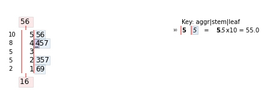

```python
# importing the module
import stemgraphic

data = [16, 25, 47, 56, 23, 45, 19, 55, 44, 27]

# calling stem_graphic with required parameters,
# data and scale
stemgraphic.stem_graphic(data, scale = 10)
```

### using custom functions

```python
from collections import OrderedDict, Counter

x= [12, 127, 28, 42, 39, 113, 42, 18, 44, 118, 44, 37, 113, 124, 37, 48,
    127, 36, 29, 31, 125, 139, 131, 115, 105, 132, 104, 123, 35, 113,
    122, 42, 117, 119, 58, 109, 23, 105, 63, 27, 44, 105, 99, 41, 128,
    121, 116, 125, 32, 61, 37, 127, 29, 113, 121, 58, 114, 126, 53, 114,
    96, 25, 109, 7, 31, 141, 46, 13, 27, 43, 117, 116, 27, 7, 68, 40, 31,
    115, 124, 42, 128, 52, 71, 118, 117, 38, 27, 106, 33, 117, 116, 111,
    40, 119, 47, 105, 57, 122, 109, 124, 115, 43, 120, 43, 27, 27, 18,
    28, 48, 125, 107, 114, 34, 133, 45, 120, 30, 127, 31, 116, 146]

def stemleaf(x):
    d = OrderedDict((((str(v)[:-1],' ')[v<10], Counter()) for v in sorted(x)))
    for s in ((str(v),' '+str(v))[v<10] for v in x) : d[s[:-1]][s[-1]]+=1
    m=max(len(s) for s in d)
    for k in d:
        print('%s%s | %s'%(' '*(m-len(k)),k,' '.join(sorted(d[k].elements()))))

stemleaf(x)
```

```
   | 7 7
 1 | 2 3 8 8
 2 | 3 5 7 7 7 7 7 7 8 8 9 9
 3 | 0 1 1 1 1 2 3 4 5 6 7 7 7 8 9
 4 | 0 0 1 2 2 2 2 3 3 3 4 4 4 5 6 7 8 8
 5 | 2 3 7 8 8
 6 | 1 3 8
 7 | 1
 9 | 6 9
10 | 4 5 5 5 5 6 7 9 9 9
11 | 1 3 3 3 3 4 4 4 5 5 5 6 6 6 6 7 7 7 7 8 8 9 9
12 | 0 0 1 1 2 2 3 4 4 4 5 5 5 6 7 7 7 7 8 8
13 | 1 2 3 9
14 | 1 6
```

### using matplotlib library

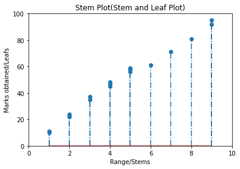

```python
import matplotlib.pyplot as plot

import numpy as np

import pylab



# marks obtained by students in an examination

marks = [10,11,22,24,35,37,45,47,48,58,56,59,61,71,81,92,95]



# corresponding stems

stems = [1,1,2,2,3,3,4,4,4,5,5,5,6,7,8,9,9]



# set the x axis and y axis limits

pylab.xlim([0,10])

pylab.ylim([0,100])



# Provide a title for the stem plot

plot.title('Stem Plot(Stem and Leaf Plot)')



# Give x axis label for the stem plot

plot.xlabel('Range/Stems')



# Give y axis label for the stem plot

plot.ylabel('Marks obtained/Leafs')



# plot the stem plot using matplotlib

markerline, stemlines, baseline = plot.stem(stems, marks, '-.')



# display the stem plot

plot.show()
```

## Components of an effective stem and leaf plot

A excellent plot of stems and leaves

- depicts the last digit (ones) as the leaf and the first digits of the number (thousands, hundreds, or tens) as the stem.
- frequently employs full numerals. The nearest whole number is used to round anything with a decimal point. For instance, when flipped on its side, test results, speeds, heights, weights, etc. resemble a bar graph.
- displays the distribution of the data, including the highest, lowest, most prevalent, and outliers (a number that lies outside the main group of numbers).

## Usage of Stem and Leaf Plot

### 1. Displaying the relative density and shape of the data

- It gives the reader a quick overview of the distribution especially when the data is not too complex..
- They retain (most of) the raw numerical data, often with perfect integrity.

Suppose you have a dataset of test scores:

```python
from collections import OrderedDict, Counter

scores= [72, 87, 56, 89, 78, 90, 82, 67, 77, 85, 94, 68, 71, 93, 79, 75, 81, 73, 88, 84]

def stemleaf(scores):
    d = OrderedDict((((str(v)[:-1],' ')[v<10], Counter()) for v in sorted(x)))
    for s in ((str(v),' '+str(v))[v<10] for v in x) : d[s[:-1]][s[-1]]+=1
    m=max(len(s) for s in d)
    for k in d:
        print('%s%s | %s'%(' '*(m-len(k)),k,' '.join(sorted(d[k].elements()))))

stemleaf(scores)
```

```
   | 7 7
 1 | 2 3 8 8
 2 | 3 5 7 7 7 7 7 7 8 8 9 9
 3 | 0 1 1 1 1 2 3 4 5 6 7 7 7 8 9
 4 | 0 0 1 2 2 2 2 3 3 3 4 4 4 5 6 7 8 8
 5 | 2 3 7 8 8
 6 | 1 3 8
 7 | 1
 9 | 6 9
10 | 4 5 5 5 5 6 7 9 9 9
11 | 1 3 3 3 3 4 4 4 5 5 5 6 6 6 6 7 7 7 7 8 8 9 9
12 | 0 0 1 1 2 2 3 4 4 4 5 5 5 6 7 7 7 7 8 8
13 | 1 2 3 9
14 | 1 6
```

### 2. Highlighting outliers and finding the mode.

- However, stem-and-leaf displays are only useful for moderately sized data sets (around 15–150 data points).

```python
def stem_leaf_outliers(data):
    # Calculate the median and quartiles of the data
    median = sorted(data)[len(data) // 2]
    q1 = sorted(data)[:len(data) // 2][len(data) // 4]
    q3 = sorted(data)[len(data) // 2 + len(data) // 4]

    # Calculate the lower and upper limits for outliers
    iqr = q3 - q1
    lower_limit = q1 - 1.5 * iqr
    upper_limit = q3 + 1.5 * iqr

    # Create a dictionary to hold the stem and leaf plot data
    stem_leaves = {}

    # Add the data points within the upper and lower limits to the stem and leaf plot
    for d in data:
        if d >= lower_limit and d <= upper_limit:
            stem = str(d // 10)
            leaf = str(d % 10)
            if stem not in stem_leaves:
                stem_leaves[stem] = []
            stem_leaves[stem].append(leaf)

    # Print the stem and leaf plot
    for stem in sorted(stem_leaves.keys()):
        leaves = " ".join(sorted(stem_leaves[stem]))
        print(stem + " | " + leaves)

    # Print the outliers
    for d in data:
        if d < lower_limit or d > upper_limit:
            print("Outlier: " + str(d))
```

```python
scores = [72, 87, 56, 89, 78, 90, 82, 67, 77, 85, 94, 68, 71, 93, 79, 75, 81, 73, 88, 84, 32, 106]
stem_leaf_outliers(scores)
```

```
10 | 6
5 | 6
6 | 7 8
7 | 1 2 3 5 7 8 9
8 | 1 2 4 5 7 8 9
9 | 0 3 4
Outlier: 32
```

This plot shows that the scores are fairly evenly distributed between the mid-60s and mid-90s, with the highest density of scores in the mid-70s and mid-80s. It also identifies one outlier with a score of 32. Overall, this plot provides a quick and easy way to identify outliers in the data.

### 3. To convey non-numerical information

- Stem-and-leaf displays can also be used to convey non-numerical information. In this example of valid two-letter words in Collins Scrabble Words (the word list used in Scrabble tournaments outside the US) with their initials as stems, it can be easily seen that the top three initials are o, a and e

[figure not shown]

Stem and leaf plots are typically used for visualizing numerical data, but they can also be used to visualize non-numerical information such as strings or categorical variables. Here's an example of how to generate a stem and leaf plot for non-numerical information in Python, using entire words:

Suppose you have a dataset of words:

```python
def stem_leaf_words(data):
    # Create a dictionary to hold the stem and leaf plot data
    stem_leaves = {}

    # Add each word to the stem and leaf plot
    for word in data:
        stem = word[0]
        leaf = word[1:]
        if stem not in stem_leaves:
            stem_leaves[stem] = []
        stem_leaves[stem].append(leaf)

    # Print the stem and leaf plot
    for stem in sorted(stem_leaves.keys()):
        leaves = " ".join(sorted(stem_leaves[stem]))
        print(stem + " | " + leaves)
```

```python
words = ["apple", "banana", "cherry", "date", "elderberry", "fig", "grape", "honeydew", "kiwi", "lemon"]
stem_leaf_words(words)
```

```
a | pple
b | anana
c | herry
d | ate
e | lderberry
f | ig
g | rape
h | oneydew
k | iwi
l | emon
```

This function takes a list of words as input, and creates a dictionary to hold the stem and leaf plot data. For each word, it uses the first letter as the stem and the remaining letters as the leaf, and adds the word to the stem and leaf plot data. Finally, it prints the stem and leaf plot.

This code calls the stem_leaf_words() function with the words list as input.

This plot shows that the words are evenly distributed across the alphabet, with one word for each stem letter. The plot provides a way to quickly see the distribution of the words in the dataset, and can be useful for identifying patterns or anomalies in the data.

## 2. Q-Q Plot

- In statistics, a Q–Q plot (quantile-quantile plot) is a probability plot, a graphical method for comparing two probability distributions by plotting their quantiles against each other.
- A point (x, y) on the plot corresponds to one of the quantiles of the second distribution (y-coordinate) plotted against the same quantile of the first distribution (x-coordinate).
- This defines a parametric curve where the parameter is the index of the quantile interval.

[figure not shown]

The quantiles of the first data set are plotted against the quantiles of the second data set in a q-q graphic. A quantile is the percentage of points that fall below the specified number. In other words, the 0.3 (or 30%) quantile is the value at which 30% of the data are below it and 70% are above it.

Moreover, **a 45-degree reference line is plotted.** The points should roughly lie along this reference line if the two sets are drawn from a population with the same distribution. The further the two data sets deviate from this reference line, the more evidence there is that they came from populations with different distributions.

```python
import numpy as np

#create dataset with 100 values that follow a normal distribution
np.random.seed(0)
data = np.random.normal(0,1, 1000)

#view first 10 values
data[:10]
```

```
array([ 1.76405235,  0.40015721,  0.97873798,  2.2408932 ,  1.86755799,
       -0.97727788,  0.95008842, -0.15135721, -0.10321885,  0.4105985 ])
```

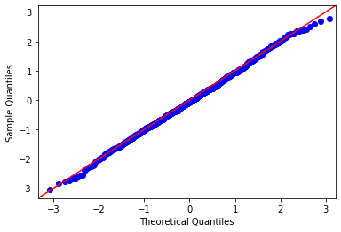

```python
import statsmodels.api as sm
import matplotlib.pyplot as plt

#create Q-Q plot with 45-degree line added to plot
fig = sm.qqplot(data, line='45')
plt.show()
```

The q-q plot is formed by:

- Vertical axis: Estimated quantiles from data set 1
- Horizontal axis: Estimated quantiles from data set 2

The units on both axes correspond to the corresponding data sets. The real quantile level is not plotted, in other words. The quantile level for a specific point on the q-q plot is known to be the same for both points, but its precise value is unknown.

The q-q plot is essentially a plot of sorted data set 1 against sorted data set 2 if the data sets are the same size. The quantiles are often chosen to match the sorted values from the smaller data set in cases when the data sets are not equal in size, and the quantiles for the bigger data set are then interpolated.

The following inquiries are addressed with the q-q plot:

- Are there common distributions between the two data sets?
- Do the scale and location of two data sets match up?
- Do the distributional forms of two data sets compare?
- Do the tails of two data sets compare?

## Usage of Q-Q plot

Q-Q plots (Quantile-Quantile plots) are a type of graphical technique used to compare two probability distributions. The primary use cases of Q-Q plots are:

1. **Testing for normality**:

Q-Q plots are commonly used to test if a dataset follows a normal distribution. If the data points fall close to the straight line on the Q-Q plot, it indicates that the data follows a normal distribution. If the data points deviate from the straight line, it suggests that the data does not follow a normal distribution.

1. **Comparing distributions**:

Q-Q plots can be used to compare two distributions to see if they are similar or different. If the two distributions are similar, the Q-Q plot will show the data points falling close to the straight line. If the two distributions are different, the Q-Q plot will show the data points deviating from the straight line.

1. **Identifying outliers**:

Q-Q plots can be used to identify outliers in a dataset. Outliers are data points that are significantly different from the other data points in the dataset. These data points will appear as points that deviate from the straight line on the Q-Q plot.

1. **Checking for linearity**:

Q-Q plots can be used to check the linearity of a relationship between two variables. If the data points fall close to the straight line on the Q-Q plot, it suggests that the relationship between the two variables is linear.

1. **Assessing model assumptions**:

Q-Q plots can be used to assess the assumptions of statistical models. If the residuals (the difference between the predicted values and the actual values) of a model follow a normal distribution, the Q-Q plot of the residuals will show the data points falling close to the straight line. If the residuals do not follow a normal distribution, the Q-Q plot will show the data points deviating from the straight line.

Overall, Q-Q plots are a useful tool for visualizing and comparing probability distributions, and can help identify patterns and anomalies in the data.

### 1. Testing for normality

```python
import numpy as np
import scipy.stats as stats
import matplotlib.pyplot as plt

def qqplot_normality_test(data):
    """
    This function generates a QQ plot for testing normality of a given data sample.

    Parameters:
        data (numpy array or pandas series): The data sample to test for normality.

    Returns:
        None
    """
    # Sort the data in ascending order
    sorted_data = np.sort(data)

    # Compute the expected quantiles for a normal distribution
    expected_quantiles = stats.norm.ppf(np.linspace(0.01, 0.99, len(data)))

    # Generate the QQ plot
    plt.figure(figsize=(8, 6))
    plt.scatter(expected_quantiles, sorted_data)
    plt.xlabel('Expected Quantiles (Normal Distribution)')
    plt.ylabel('Observed Quantiles (Data Sample)')
    plt.title('Q-Q Plot for Normality Test')
    plt.show()
```

This function takes a data sample as input and generates a QQ plot for testing the normality of the data.

Finally, the function generates the QQ plot using the plt.scatter() function and adds labels and a title to the plot using the plt.xlabel(), plt.ylabel(), and plt.title() functions. The resulting plot will show how closely the data sample follows a normal distribution. If the points fall along a straight line, it suggests that the data is normally distributed. If the points deviate from the straight line, it indicates that the data is not normally distributed.

To use this function, you simply need to pass in a numpy array or pandas series containing your data sample. For example, if you have a numpy array called my_data containing your data, you would call the function like this:

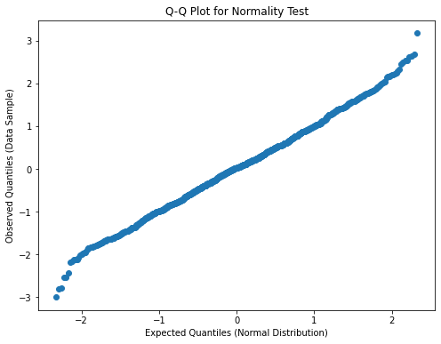

```python
my_data = np.random.normal(0,1, 1000)
qqplot_normality_test(my_data)
```

```python
# Set the parameters of the beta distribution
alpha = 2
beta = 5

# Generate a sample of 1000 random numbers from the beta distribution
sample = np.random.beta(alpha, beta, size=1000)
```

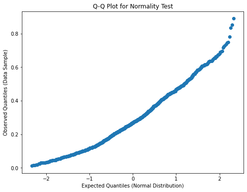

```python
qqplot_normality_test(sample)
```

The first graphs forms striaght line and confirms that it is a normal distribution but the second graph is a curve which proves that QQ plot can be used as a test of Normaility

### 2. Comparing Distributions

Q-Q plots can be used to compare any probability distribution to a reference distribution, including beta distributions.

To create a Q-Q plot for a beta distribution, you would first need to generate a random sample from the beta distribution that you want to compare to the reference distribution. Then, you would plot the quantiles of the sample against the quantiles of the reference distribution on a scatter plot.

The Q-Q plot will show how well the beta distribution fits the reference distribution. If the data points on the Q-Q plot follow a straight line, it suggests that the beta distribution is a good fit for the reference distribution. If the data points deviate from the straight line, it indicates that the beta distribution is not a good fit.

It's worth noting that beta distributions can take on different shapes depending on the values of the parameters alpha and beta. Therefore, it may be useful to create multiple Q-Q plots with different parameter values to compare how well the beta distribution fits the reference distribution under different scenarios.

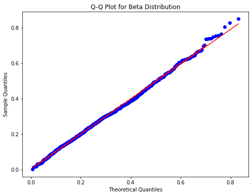

```python
import numpy as np
import scipy.stats as stats
import matplotlib.pyplot as plt

# Set the parameters of the beta distribution
alpha = 2
beta = 5

# Generate a sample of 1000 random numbers from the beta distribution
sample = np.random.beta(alpha, beta, size=1000)

# Generate the theoretical quantiles for a beta distribution with the same parameters
beta_dist = stats.beta(alpha, beta)
quantiles = beta_dist.ppf(np.linspace(0.01, 0.99, 100))

# Create the Q-Q plot
plt.figure(figsize=(8, 6))
stats.probplot(sample, dist=beta_dist, plot=plt)
plt.plot(quantiles, quantiles, color='red', linestyle='--')
plt.xlabel('Theoretical Quantiles')
plt.ylabel('Sample Quantiles')
plt.title('Q-Q Plot for Beta Distribution')
plt.show()
```

In this code, we first set the parameters alpha and beta for the beta distribution. We then generate a sample of 1000 random numbers from the beta distribution using the np.random.beta() function.

Next, we generate the theoretical quantiles for the beta distribution with the same parameters using the stats.beta.ppf() function, which computes the inverse of the cumulative distribution function for the beta distribution. We generate 100 quantiles between 0.01 and 0.99.

Finally, we create the Q-Q plot using the stats.probplot() function, which takes the sample and the reference distribution as arguments. We also plot the line of perfect fit using the plt.plot() function, and add labels and a title to the plot using the plt.xlabel(), plt.ylabel(), and plt.title() functions.

This code will create a Q-Q plot showing how well the sample of data fits a beta distribution with the given parameters. You can change the values of alpha and beta to create Q-Q plots for different beta distributions.

### 3. Identifying outliers

This function works in a similar way to the previous function, but with an additional step for identifying outliers. After computing the expected quantiles and sorting the data, the function computes the absolute differences between the observed and expected quantiles using np.abs(). It then computes the median absolute deviation (MAD) of these differences using np.median().

```python
import numpy as np
import scipy.stats as stats
import matplotlib.pyplot as plt

def qqplot_outliers(data):
    """
    This function generates a QQ plot for identifying outliers in a given data sample.

    Parameters:
        data (numpy array or pandas series): The data sample to test for outliers.

    Returns:
        None
    """
    # Sort the data in ascending order
    sorted_data = np.sort(data)

    # Compute the expected quantiles for a normal distribution
    expected_quantiles = stats.norm.ppf(np.linspace(0.01, 0.99, len(data)))

    # Compute the absolute differences between observed and expected quantiles
    absolute_diff = np.abs(sorted_data - expected_quantiles)

    # Compute the median absolute deviation
    mad = np.median(absolute_diff)

    # Generate the QQ plot
    plt.figure(figsize=(8, 6))
    plt.scatter(expected_quantiles, sorted_data)
    plt.xlabel('Expected Quantiles (Normal Distribution)')
    plt.ylabel('Observed Quantiles (Data Sample)')
    plt.title('Q-Q Plot for Identifying Outliers')
    plt.plot([expected_quantiles[0], expected_quantiles[-1]], [expected_quantiles[0] - mad, expected_quantiles[-1] + mad], color='r')
    plt.show()
```

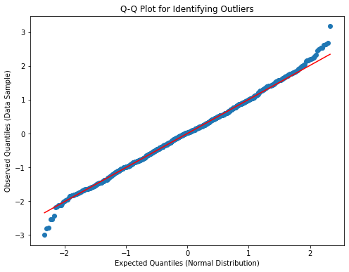

```python
qqplot_outliers(my_data)
```

### 4. Checking for linearity

This function takes two arguments, x and y, which should be numpy arrays or pandas series containing the values of the two variables you want to check for linearity. The function computes the expected quantiles for a normal distribution using stats.norm.ppf(), and sorts the data for each variable in ascending order using np.sort(). It then computes the quantiles for each variable using stats.rankdata(), which converts the sorted data to a percentage of the total number of observations.

The QQ plot is generated using plt.scatter(), with the expected quantiles on the x-axis and the quantiles for the second variable on the y-axis. We add a red line to the plot using plt.plot(), which represents a perfectly linear relationship between the two variables. If the scatter plot of the quantiles closely follows the red line, it suggests that the two variables are linearly related.

To use this function, you simply need to pass in the numpy arrays or pandas series containing your two variables. For example, if you have numpy arrays called x and y containing your variables, you would call the function like this:

```python
import numpy as np
import scipy.stats as stats
import matplotlib.pyplot as plt

def qqplot_linearity(x, y):
    """
    This function generates a QQ plot to check for linearity between two variables.

    Parameters:
        x (numpy array or pandas series): The values of the first variable.
        y (numpy array or pandas series): The values of the second variable.

    Returns:
        None
    """
    # Compute the expected quantiles for a normal distribution
    expected_quantiles = stats.norm.ppf(np.linspace(0.01, 0.99, len(x)))

    # Sort the data for each variable in ascending order
    sorted_x = np.sort(x)
    sorted_y = np.sort(y)

    # Compute the quantiles for each variable
    quantiles_x = stats.rankdata(sorted_x) / len(sorted_x)
    quantiles_y = stats.rankdata(sorted_y) / len(sorted_y)

    # Generate the QQ plot
    plt.figure(figsize=(8, 6))
    plt.scatter(expected_quantiles, quantiles_y)
    plt.xlabel('Expected Quantiles (Normal Distribution)')
    plt.ylabel('Observed Quantiles (Second Variable)')
    plt.title('Q-Q Plot for Checking Linearity')
    plt.plot([0, 1], [0, 1], color='r')
    plt.show()
```

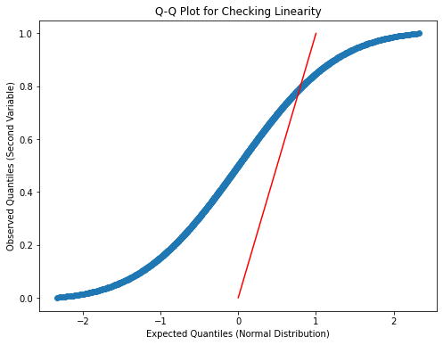

```python
x1 = np.random.normal(1,2,1000)
x2 = np.random.normal(1,2,1000)
qqplot_linearity(x1, x2)
```

## 3. SPLOM (Scatter Plot Matrix)

Scatter plot matrix is a matrix (or grid) of scatter plots where each scatter plot in the grid is created between different combinations of variables. In other words, scatter plot matrix represents bi-variate or pairwise relationship between different combinations of variables while laying them in grid form.

A scatterplot matrix, also known as a pair plot or SPLOM, is a visualization tool that allows you to explore relationships between multiple variables. Here are some of the more common uses of the scatter matrix:

1. **Exploratory Data Analysis**:

The scatter matrix is often used in exploratory data analysis to visualize relationships between multiple variables in a data set. By looking at scatter plots, you can quickly identify interesting patterns or trends in the data, as well as any outliers or outliers.

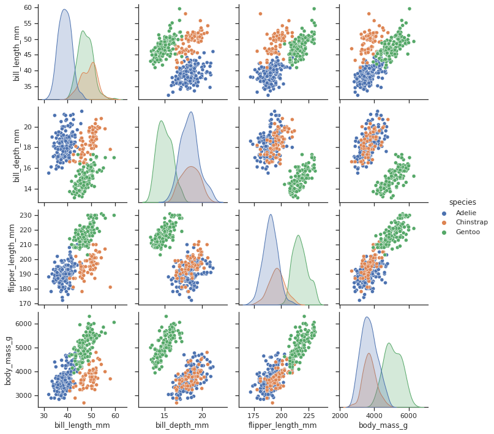

```python
import seaborn as sns
sns.set_theme(style="ticks")

df_penguins = sns.load_dataset("penguins")
sns.pairplot(df_penguins, hue="species")
```

1. **Correlation analysis**:

A covariance matrix can be used to analyze the correlation between variables. By looking at scatterplots, you can see whether there is a linear or non-linear relationship between each pair of variables, and whether the relationship is positive or negative.

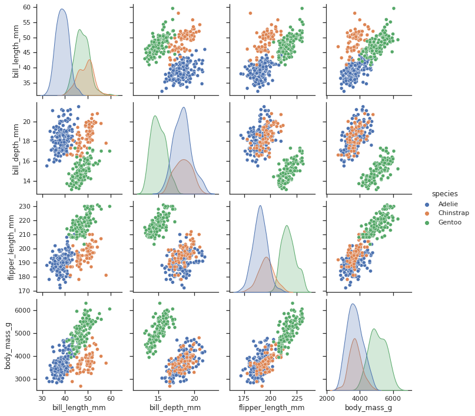

```python
sns.pairplot(df_penguins, hue='species')
plt.show()
```

1. **Multivariate Analysis**:

A covariance matrix can be used to visualize the relationship between multiple variables in a data set. This can be useful if you have many variables and want to see how they relate to each other.

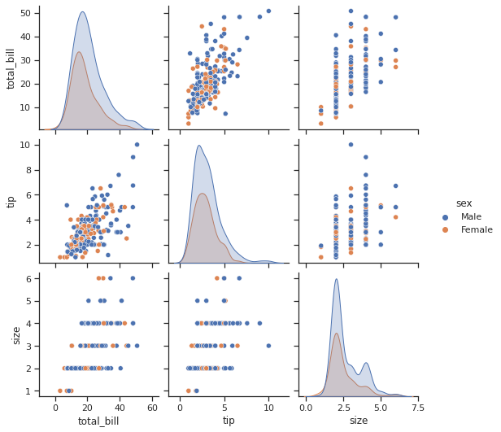

```python
df_tips = sns.load_dataset('tips')
sns.pairplot(df_tips, hue='sex')
plt.show()
```

1. **Feature Selection**:

A disambiguation matrix can be used to select the most important features for a predictive model. By looking at scatterplots, you can see which variables are most strongly correlated with the target variable and which are not.

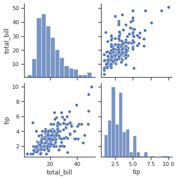

```python
sns.pairplot(df_tips, vars=['total_bill', 'tip'])
plt.show()
```

1. **Outlier Detection**:

A scatter matrix can be used to detect outliers in a dataset. Outliers are data points that are significantly different from other data points and can be identified by looking at scatterplots.

```python
import plotly.express as px
df_iris = px.data.iris()
```

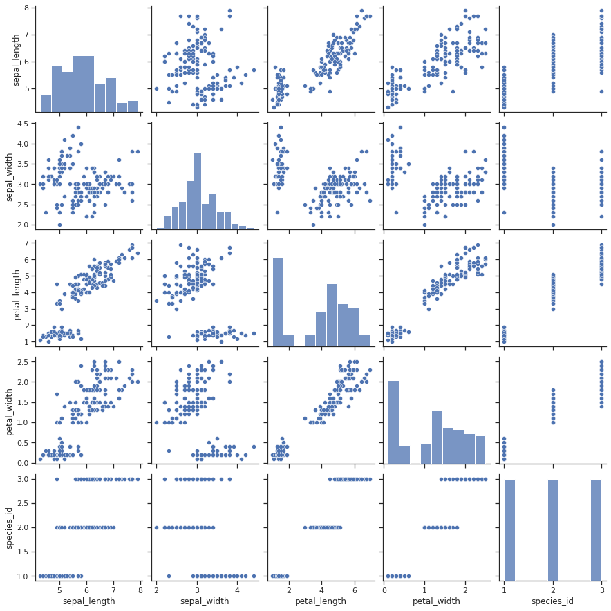

```python
sns.pairplot(df_iris, diag_kind='hist')
plt.show()
```

In conclusion, the disc matrix is a powerful tool for exploring the relationships between multiple variables in a dataset and can be used for a variety of data analysis tasks, from exploratory data analysis to feature selection and outlier detection.

## 4. Parallel Coordinates

- A Parallel coordinates plot is used to analyze multivariate numerical data. It allows a comparison of the samples or observations across multiple numerical variables.
- Each feature/variable is represented by a separate axis. All the axes are equally spaced and parallel to each other. Each axis can have a different scale and unit of measurement.
- Each sample/observation is plotted horizontally.

Parallel coordinates plot is a useful tool for visualizing high-dimensional data. Here are some use cases of parallel coordinates plot:

1. **Multivariate analysis**:

Parallel coordinates plot can be used to visualize and analyze multivariate data. It allows us to plot multiple variables on the same plot and observe the patterns and relationships between them.

```python
! pip install plotly
```

```python
fig = px.parallel_coordinates(df_iris, color="species_id",
                              dimensions=['sepal_width', 'sepal_length', 'petal_width',
                                          'petal_length'],
                              color_continuous_scale=px.colors.diverging.Tealrose,
                              color_continuous_midpoint=2)
fig.show()
```

[interactive chart not shown]

```python
df_iris.head()
```

|  | sepal_length | sepal_width | petal_length | petal_width | species | species_id |
| --- | --- | --- | --- | --- | --- | --- |
| 0 | 5.1 | 3.5 | 1.4 | 0.2 | setosa | 1 |
| 1 | 4.9 | 3.0 | 1.4 | 0.2 | setosa | 1 |
| 2 | 4.7 | 3.2 | 1.3 | 0.2 | setosa | 1 |
| 3 | 4.6 | 3.1 | 1.5 | 0.2 | setosa | 1 |
| 4 | 5.0 | 3.6 | 1.4 | 0.2 | setosa | 1 |

1. **Classification**:

Parallel coordinates plot can be used to classify data points based on their values. By plotting the different classes on the same plot, we can observe how they differ from each other and identify any patterns or trends that can help us distinguish them.

```python
fig = px.parallel_coordinates(df_iris, color="species_id",
                              color_continuous_scale=px.colors.diverging.Tealrose,
                              color_continuous_midpoint=2)
fig.show()
```

[interactive chart not shown]

1. **Outlier detection**:

Parallel coordinates plot can be used to identify outliers in the data. Outliers are data points that have values significantly different from the rest of the data, and they can be easily identified in a parallel coordinates plot as they do not follow the same pattern as the other data points.

```python
fig = px.parallel_coordinates(df_iris, color="species_id",
                              dimensions=['sepal_width', 'sepal_length', 'petal_width',
                                          'petal_length'])
fig.show()
```

[interactive chart not shown]

1. **Feature selection**:

Parallel coordinates plot can be used to select the most important features for a predictive model. By plotting the different features on the same plot and observing their patterns and relationships with the target variable, we can identify the features that are most relevant for the prediction task.

```python
fig = px.parallel_coordinates(df_iris, dimensions=['sepal_width', 'sepal_length', 'petal_width',
                                          'petal_length'],
                              color_continuous_scale=px.colors.diverging.Tealrose,
                              color_continuous_midpoint=2)
fig.show()
```

[interactive chart not shown]

1. **Data exploration**:

Parallel coordinates plot can be used to explore the data and gain insights about its structure and patterns. It allows us to visualize and analyze high-dimensional data in a more intuitive way and identify any interesting relationships or trends that may not be apparent in lower-dimensional visualizations.

```python
fig = px.parallel_coordinates(df_iris, dimensions=['sepal_width', 'sepal_length', 'petal_width',
                                          'petal_length'], color="species_id", color_continuous_scale=px.colors.diverging.Tealrose, color_continuous_midpoint=2)
fig.show()
```

[interactive chart not shown]

# References -

1. A Tour through the Visualization Zoo By Jeffrey Heer, Michael Bostock, and Vadim Ogievetsky, Stanford University https://queue.acm.org/detail.cfm?id=1805128
2. Chat GPT website [https://chat.openai.com/chat]
3. Stemgraphic [https://pypi.org/project/stemgraphic/]

# License

All code in this notebook is available as open source through the MIT license.

All text and images are free to use under the Creative Commons Attribution 3.0 license. https://creativecommons.org/licenses/by/3.0/us/

These licenses let people distribute, remix, tweak, and build upon the work, even commercially, as long as they give credit for the original creation.

Copyright 2023 AI Skunks https://github.com/aiskunks

Permission is hereby granted, free of charge, to any person obtaining a copy of this software and associated documentation files (the "Software"), to deal in the Software without restriction, including without limitation the rights to use, copy, modify, merge, publish, distribute, sublicense, and/or sell copies of the Software, and to permit persons to whom the Software is furnished to do so, subject to the following conditions:

The above copyright notice and this permission notice shall be included in all copies or substantial portions of the Software.

THE SOFTWARE IS PROVIDED "AS IS", WITHOUT WARRANTY OF ANY KIND, EXPRESS OR IMPLIED, INCLUDING BUT NOT LIMITED TO THE WARRANTIES OF MERCHANTABILITY, FITNESS FOR A PARTICULAR PURPOSE AND NONINFRINGEMENT. IN NO EVENT SHALL THE AUTHORS OR COPYRIGHT HOLDERS BE LIABLE FOR ANY CLAIM, DAMAGES OR OTHER LIABILITY, WHETHER IN AN ACTION OF CONTRACT, TORT OR OTHERWISE, ARISING FROM, OUT OF OR IN CONNECTION WITH THE SOFTWARE OR THE USE OR OTHER DEALINGS IN THE SOFTWARE.